# Loan Data

## 2- APR

**Let's see if the Credit score has anything to do with ARP**

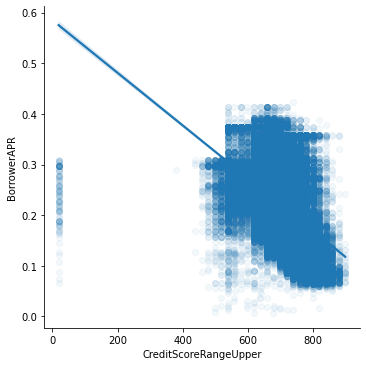

```python
sns.lmplot(data=df, x='CreditScoreRangeUpper', y='BorrowerAPR', x_jitter=0.3, scatter_kws={'alpha':1/20})
```

Well, a negative slop it is. The higher the credit score the less the APR

**Would the APR differ significantly depending on the duration of the loan**?

> technically, "Term" is a numerical variable but it only takes 3 values so it makes sense to deal with at as a categorical variable

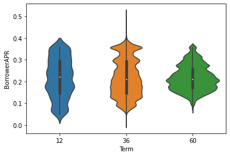

```python
sns.violinplot(data=df, x='Term', y='BorrowerAPR')
```

While the APR for loans of duration 12 and 36 Terms look roughly evenly distrubuted, it seems loans of a duration 60 months are concentrated around the median.  
It does not seem, however, that there is a strong correlation between the loan duration and APR

```python
df['Term'].corr(df['BorrowerAPR'])
```

```
-0.011186895144124076
```

**What is the relationship between APR and BorrowerRate??**

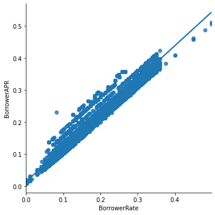

```python
sns.lmplot(data=df, x='BorrowerRate', y='BorrowerAPR')#, x_jitter=0.7, scatter_kws={'alpha':1/2})
```

Never seen a more obvious linear relationship...They are pretty much redundant

**What about Income?**

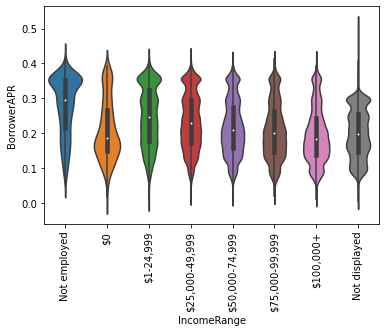

```python
sns.violinplot(data=df, x='IncomeRange', y='BorrowerAPR')# order=['$100,000+',
 #'$75,000-99,999', '$50,000-74,999', '$25,000-49,999', '$1-24,999', '$0', 'Not employed'])
plt.xticks(rotation=90);
```

We can see the APR bulk of each part of the violin plot going up slightly as the income range goes down...  
Weridly though, for those who have no income the average APR is as low as those who have income of 100000+ !!

**Does Recommendations has any impact on APR?**

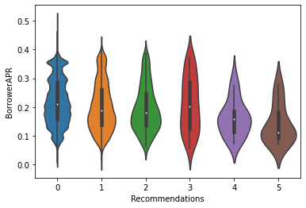

```python
sns.violinplot(data=df[df['Recommendations']<6], x='Recommendations', y='BorrowerAPR')
```

Diffiicult to interpret given our knowledge that for those who have more than 3 reecommendations we don't have enough data so we shouldn't rush to conclude that recommendations increases your chance in a lower APR.  
For the number of recommendations for which we have a relatively satisfactory sample size (0-3), the inverse correlation is even weaker

Let's go ahead and fit a line Nonetheless

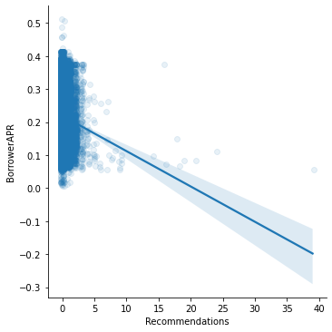

```python
sns.lmplot(data=df, x='Recommendations', y='BorrowerAPR', x_jitter=0.3, scatter_kws={'alpha':1/10});
```

**What about the number of investors and the amount of the loan?**

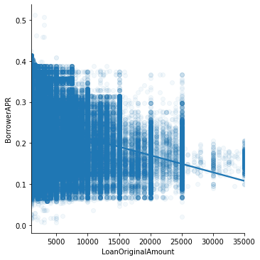

```python
sns.lmplot(data=df, x='LoanOriginalAmount', y='BorrowerAPR', x_jitter=0.3, scatter_kws={'alpha':1/20});
```

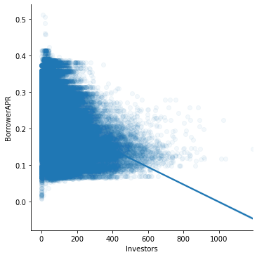

```python
sns.lmplot(data=df, x='Investors', y='BorrowerAPR', x_jitter=0.3, scatter_kws={'alpha':1/20});
```

The regression lines shows an inverse relationship between APR and both the number of investors and the amount of the loan.

**One last thing! Does APR and the loan completion rate have anything to do with one another?**

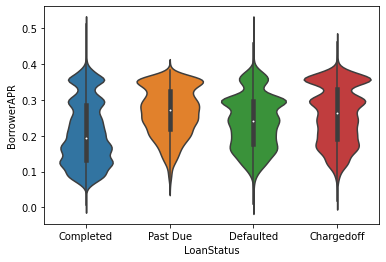

```python
sns.violinplot(data=df[df['LoanStatus']!='Current'], x='LoanStatus', y='BorrowerAPR')
```

Well, lower APR seem to increase the chances of a loan getting completed

## Multivariate Exploration

We didn't find a clear relationship between loan amount and loan completion let's see if this still holds for each income range

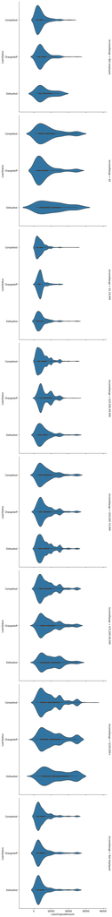

```python
g = sns.FacetGrid(data = df[df['LoanStatus']!='Current'], row = 'IncomeRange', height =7,
                margin_titles = True)
g.map(sns.violinplot, 'LoanOriginalAmount', 'LoanStatus')
```

Apparently it sill holds except for income ranges that have few samples for which the difference in distribution is probably due to randomness.